# 수업 운영 방식

o 출결 관리: 강의 시작 시간에 호명으로 체크한다. 지각은 4번마다 1회 결석으로 간주한다.

```
 -  "질병, 공적행사참석"등으로 결석한 경우 2일 이내(즉 결석일 익일까지)에 email 로 사유증빙을 보내야 면제 받는다.
```

o 숙제 및 과제 관리

```
 - 마감 5일 이내 제출은 10% 만 감점함. 그 이후는 1일 마다 5%추가감점; 마감 10일이 넘은 제출은 받지 않음.
```

o 연습시간: 운영시간: 금 10:20 ~ 10:50am;

```
 - 수강생들의 질문(email, 문자, 당일질의)에 대하여 조교가 답변해 주는 시간으로 활용한다.
```

o 조교정보: 김송우 (swkim@yonsei.ac.kr; 010-3212-4639)

# Introduction to AI

**인공지능이란**

- 사람과 유사한 지능을 가지도록,
- 인간의 `학습`능력, `추론`능력, `지각`능력, `자연어이해` 능력, 행동능력을 가지는 기계를 만드는 기술이다.

**인공지능의 분야**

- 자연어 처리(Natural Language Processing)
  - Conversation(대화형)
  - 기계번역
  - 감정분석
  - 내용분석
- Speech Recognition
  - Speech to Text
  - Text to Speech
- Computer Vision
  - 이미지
  - 비디오

## 기계학습

최근 인공지능 발전의 주 동력원이 되는 기술이다.  
기계 스스로 대량의 데이터에서 지식이나 패턴을 찾아 학습하여, 새로운 입력이나 상황에 대해 출력을 예측하는 시스템을 달성하는 기술이다.

**Arthur Samuel**:  
*명시적으로 프로그램을 작성하지 않고 컴퓨터에 학습할 수 있는 능력을 부여하기 위한 연구 분야*

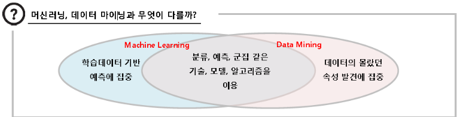

**인공지능의 발전 방향**

- 연결주의(Connectionism)
  - 지능은 복잡하게 연결된 신경망에 의해 이루어진다.
  - 다층 퍼셉트론은 비선형 분리도 가능하다.
- 기호주의(Symbolism)
  - 1970년대 중반 ~ 1980년대 후반까지 인공지능의 핵심 접근법이었다.
  - 기호를 통해 개념을 정의하고, 이 기호들을 가지고 일정한 논리적 규칙에 따라 추론한다.
  - 전문가 시스템으로 발전했다.

**기계학습의 현대적 재정의**

- Tom Mitchell(Carnegie Mellon University, 1997)
  - 만약 캄퓨터 프로그램이 특정한 작업 T를 수행할 때 성능이 P만큼 개선도ㅚ는 경험 E를 보이면, 그 컴퓨터 프로그램은 작업 T와 성능 P에 대해 경험 E를 학습했다고 할 수 있다.

### 기계학습의 분류

| 유형 | 작업 | 알고리즘 |
| --- | --- | --- |
| 지도학습(Supervised Learning) | 분류(Classification), 예측(Prediction) | KNN, SVM, Decision Tree, Logistic Regression, Linear Regression |
| 비지도학습(Unsupervised Learning) | 군집(Clustering) | K-means Clustering, DBSCAN Clustering, Hierarchical Clustering |
| 강화학습(Reinforcement Learning) | 로봇, 게임 등에 활용 | MDP: Markov Decision Process |